# Initial machine learning analysis for drug repurposing based on diversity and count features

Wytze Vlietstra

11/6/2017

# Introduction

As agreed during the meetings between myself, Tareq, Erik, and Christina, I shall perform a machine learning analysis of the features extracted by Tareq from the Euretos Knowledge platform.

The current reference set is based on the work of Guney et al., while the negative sets consist of 10 random combinations of drugs and diseases from these sets.

Both the reference sets and the negative sets are divided between a “count”, and a “diversity” set. The “count” set appear to be the semantic types, while the “diversity” set appear to be the semantic categories.

## Initial analysis of the feature sets

It appears that for not all instances features could be extracted. For example, the positive “diversity” file has information about 403 rows, while the “count” file only has 392. There are similar mismatches between the files for the negative sets.

## Method

- Random forests
- Neural networks
- SVM
- Logistic regression

For all machine learning algorithms, standard settings are used. Classification performance is measured with a ROC-Area Under the Curve (AUC), based on a 10-fold cross validation. Classifications for all 10 negative files are performed, after which a mean ROC-AUC, and its standard deviation are given. Furthermore, the sensitivity and the specificity of the classification are also provided.

The random forests algorithm is analysed in a little more detail. Here, a high level error analysis is performed by plotting a histogram of the misclassified instances, and the feature importances are calculated.

# Implementation

First, the required packages are loaded.

```r
## Required packages
require(knitr)
require(caret)
require(randomForest)
require(plyr)
require(nnet)
require(kernlab)
require(doMC)
registerDoMC(cores = 3)
```

Then, the positive and negative cases are loaded. First, the disease “aplastic anemia” is removed. Guney mentioned in his supplemental materials that this is a potential side effect of Felbamate, and not a treatment. By removing this instance, the number of positive instances corresponds with the number of positive instances of Guney again. For each set of negative cases, a classification is executed.

```r
# Read in the files
pos_count = read.csv("Datasets/count_pos.csv", stringsAsFactors = F)
pos_div = read.csv("Datasets/diversity_pos.csv", stringsAsFactors = F)
pos_complete = merge(pos_count, pos_div, by = intersect(colnames(pos_count), colnames(pos_div)), all = T)
pos_complete = pos_complete[-which(pos_complete$Disease == "anemia aplastic"), ] # Guney's SM mention that this is invalid
pos_complete$goldstandard = "VALID"

# Output matrices for performance metrics
performance_metrics_RF = data.frame()
performance_metrics_NN = data.frame()
performance_metrics_GLM = data.frame()
performance_metrics_SVM = data.frame()

# Outcome matrix for feature importances and misclassifications
variable_importances = as.data.frame(matrix(nrow = 0, ncol = ncol(pos_complete)))
colnames(variable_importances) = colnames(pos_complete)

misclassification_scores = c()

max_file_index = 9
for(i in 0:max_file_index){
  print(paste("Analysing file index", i))
  neg_count = read.csv(paste("Datasets/count_neg_", i, ".csv", sep = ""), stringsAsFactors = F)
  neg_div = read.csv(paste("Datasets/diversity_neg_", i, ".csv", sep = ""), stringsAsFactors = F)
  neg_complete = merge(neg_count, neg_div, by = intersect(colnames(neg_count), colnames(neg_div)), all = T)
  neg_complete = neg_complete[-which(neg_complete$Disease == "anemia aplastic"), ] # Guney's SM mention that this is invalid
  neg_complete$goldstandard = "INVALID"

  full_set = rbind.fill(pos_complete, neg_complete)
  full_set[is.na(full_set)] = 0

  input = full_set[,7:ncol(full_set)]
  goldstandard = input$goldstandard
  input$goldstandard = NULL

  # Random forests
  model = train(x = input, y = goldstandard, method = "rf",
                trControl=trainControl(method="cv",number=10, classProbs = TRUE,
                                       savePredictions = TRUE, summaryFunction = twoClassSummary),
                prox=TRUE, allowParallel=TRUE, metric = "ROC")

  performance_metrics_RF = rbind(performance_metrics_RF, model$results[model$results$mtry == model$bestTune$mtry, c("ROC", "Sens", "Spec")])
  model_importances = as.data.frame(t(varImp(model)$importance))
  variable_importances = rbind.fill(variable_importances, model_importances)

  #hist(model$finalModel$votes[,"VALID"], breaks = 20)
  misclassification_scores = append(misclassification_scores,
  model$finalModel$votes[which(ifelse(model$finalModel$predicted == model$finalModel$y, 1, 0) == 0),"VALID"])

  # Neural network
  model = train(x = input, y = goldstandard, method = "nnet",
                trControl=trainControl(method="cv",number=10, classProbs = TRUE,
                savePredictions = TRUE, summaryFunction = twoClassSummary), metric = "ROC")

  performance_metrics_NN = rbind(performance_metrics_NN,
                           model$results[which(model$results$size == model$bestTune$size & model$results$decay == model$bestTune$decay), c("ROC", "Sens", "Spec")])
  # Linear regression
  model = train(x = input, y = goldstandard, method = "glm",
                trControl=trainControl(method="cv",number=10, classProbs = TRUE,
                                       savePredictions = TRUE, summaryFunction = twoClassSummary), metric = "ROC")
  performance_metrics_GLM = rbind(performance_metrics_GLM, model$results[,c("ROC", "Sens", "Spec")])

  # SVM
  model = train(x = input, y = goldstandard, method = "svmRadial",
                trControl=trainControl(method="cv",number=10, classProbs = TRUE,
                                       savePredictions = TRUE, summaryFunction = twoClassSummary), metric = "ROC")

  performance_metrics_SVM = rbind(performance_metrics_SVM,
                                  model$results[which(model$results$sigma == model$bestTune$sigma & model$results$C == model$bestTune$C),c("ROC", "Sens", "Spec")])
  }
```

# Results

## Random forest classification results

```r
# Classification performances
performance_metrics_RF = rbind(performance_metrics_RF, apply(performance_metrics_RF, 2, mean), apply(performance_metrics_RF, 2, sd))
performance_metrics_RF = cbind(data.frame(file_index = c(seq(0, max_file_index), "Mean", "SD")), performance_metrics_RF)

kable(performance_metrics_RF, format = "pandoc", digits = 3, row.names = F)
```

| file_index | ROC | Sens | Spec |
| --- | --- | --- | --- |
| 0 | 0.883 | 0.742 | 0.841 |
| 1 | 0.858 | 0.721 | 0.811 |
| 2 | 0.847 | 0.726 | 0.831 |
| 3 | 0.896 | 0.787 | 0.851 |
| 4 | 0.866 | 0.759 | 0.831 |
| 5 | 0.867 | 0.722 | 0.838 |
| 6 | 0.875 | 0.747 | 0.828 |
| 7 | 0.858 | 0.744 | 0.799 |
| 8 | 0.872 | 0.699 | 0.849 |
| 9 | 0.897 | 0.770 | 0.858 |
| Mean | 0.872 | 0.742 | 0.834 |
| SD | 0.016 | 0.026 | 0.018 |

As can be seen, performance is high for this task.

### Feature importances for random forests

The random forest algorithm allows us to see which variables are most important. Here, the top 10 are shown

```r
# Variable importance of random forest
variable_importances[is.na(variable_importances)] = 0
variable_importances = rbind(variable_importances, colSums(variable_importances))

kable(t(sort(variable_importances[nrow(variable_importances), ], decreasing = T)[1:10]), format = "pandoc", row.names = TRUE, col.names = "Importance score")
```

|  | Importance score |
| --- | --- |
| Human | 985.7100 |
| Pharmacologic.Substance | 827.8410 |
| Organic.Chemical | 598.4111 |
| Clinical.Drug | 467.7403 |
| Patient.or.Disabled.Group | 309.3211 |
| Chemicals…Drugs | 305.2393 |
| Population.Group | 280.9596 |
| Receptor | 249.6276 |
| Chemical.Viewed.Structurally | 237.0580 |
| Cell.Component | 207.2565 |

### Histogram of the random forest misclassifications

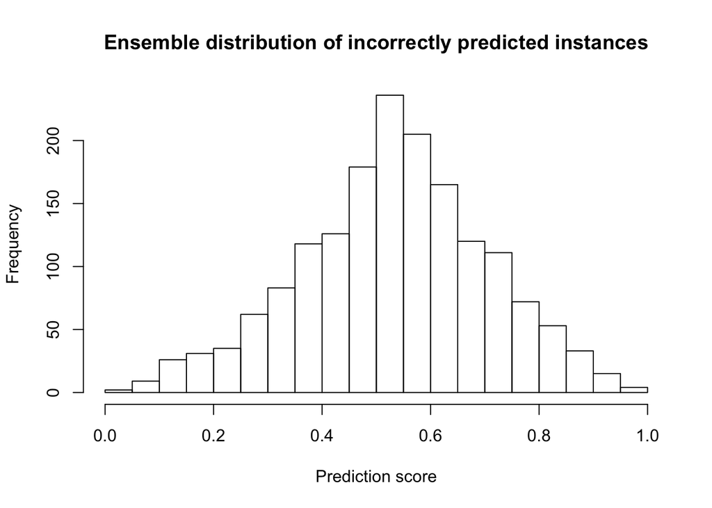

```r
hist(misclassification_scores,
     breaks = 20, main ="Ensemble distribution of incorrectly predicted instances", xlab = "Prediction score")
```

As can be seen in the ensemble histogram, i.e. from all the negative files, the errors are roughly normally distributed, which is something we should want.

## Neural networks

The neural networks results are shown below

```r
performance_metrics_NN = rbind(performance_metrics_NN, apply(performance_metrics_NN, 2, mean), apply(performance_metrics_NN, 2, sd))
performance_metrics_NN = cbind(data.frame(file_index = c(seq(0, max_file_index), "Mean", "SD")), performance_metrics_NN)

kable(performance_metrics_NN, format = "pandoc", digits = 3, row.names = F)
```

| file_index | ROC | Sens | Spec |
| --- | --- | --- | --- |
| 0 | 0.848 | 0.762 | 0.786 |
| 1 | 0.824 | 0.756 | 0.781 |
| 2 | 0.834 | 0.735 | 0.743 |
| 3 | 0.854 | 0.807 | 0.763 |
| 4 | 0.831 | 0.779 | 0.729 |
| 5 | 0.837 | 0.797 | 0.761 |
| 6 | 0.858 | 0.804 | 0.771 |
| 7 | 0.816 | 0.717 | 0.786 |
| 8 | 0.829 | 0.744 | 0.749 |
| 9 | 0.864 | 0.808 | 0.786 |
| Mean | 0.840 | 0.771 | 0.766 |
| SD | 0.016 | 0.033 | 0.020 |

As can be seen, Neural Networks perform similarly high for this task

## SVM

The SVM results are shown below

```r
performance_metrics_SVM = rbind(performance_metrics_SVM, apply(performance_metrics_SVM, 2, mean), apply(performance_metrics_SVM, 2, sd))
performance_metrics_SVM = cbind(data.frame(file_index = c(seq(0, max_file_index), "Mean", "SD")), performance_metrics_SVM)

kable(performance_metrics_SVM, format = "pandoc", digits = 3, row.names = F)
```

| file_index | ROC | Sens | Spec |
| --- | --- | --- | --- |
| 0 | 0.600 | 0.070 | 0.978 |
| 1 | 0.615 | 0.080 | 0.980 |
| 2 | 0.535 | 0.038 | 0.973 |
| 3 | 0.638 | 0.068 | 0.968 |
| 4 | 0.499 | 0.045 | 0.975 |
| 5 | 0.641 | 0.058 | 0.978 |
| 6 | 0.658 | 0.068 | 0.980 |
| 7 | 0.510 | 0.028 | 0.983 |
| 8 | 0.496 | 0.150 | 0.878 |
| 9 | 0.584 | 0.160 | 0.872 |
| Mean | 0.578 | 0.076 | 0.956 |
| SD | 0.063 | 0.045 | 0.043 |

As can be seen, SVM’s appear to perform very poorly for this task.

## Logistic regression

The Logistic regression results are shown below

```r
performance_metrics_GLM = rbind(performance_metrics_GLM, apply(performance_metrics_GLM, 2, mean), apply(performance_metrics_GLM, 2, sd))
performance_metrics_GLM = cbind(data.frame(file_index = c(seq(0, max_file_index), "Mean", "SD")), performance_metrics_GLM)

kable(performance_metrics_GLM, format = "pandoc", digits = 3, row.names = F)
```

| file_index | ROC | Sens | Spec |
| --- | --- | --- | --- |
| 0 | 0.746 | 0.652 | 0.724 |
| 1 | 0.706 | 0.654 | 0.701 |
| 2 | 0.737 | 0.711 | 0.657 |
| 3 | 0.741 | 0.701 | 0.710 |
| 4 | 0.731 | 0.696 | 0.717 |
| 5 | 0.796 | 0.749 | 0.746 |
| 6 | 0.785 | 0.762 | 0.709 |
| 7 | 0.737 | 0.716 | 0.711 |
| 8 | 0.733 | 0.678 | 0.689 |
| 9 | 0.802 | 0.728 | 0.734 |
| Mean | 0.751 | 0.705 | 0.710 |
| SD | 0.032 | 0.037 | 0.025 |

As can be seen, the logistic regression results are also high. This is a double message, because if a logistic regression is able to solve this problem, why use machine learning at all? Perhaps this is a point for discussion?

# Overall

Results appear to be good; perhaps a bit too good. I haven’t performed more detailed analyses yet, such as splitting the dataset into two separate pieces, as suggested by Guney. Furthermore, we should really take a closer look at the influence of publication bias. It could very well be that the high performance is caused by that. Random forests appear to perform best. This corresponds with our experience in our own research, although Neural Networks are not that far behind. To conclude, the good news is that performance is not horrible. That should motivate us to keep working on this. However, for now I feel the performance is unrealistically high.

# Other remarks

I see Tareq uses multiple Euretos identifiers for diseases, but I get the idea that free-text labels are used. These are less precise than codes, which can fuzz results.

For example, arthritis has MeSH identifier D001168. If you use this identifier to search for concepts, you get only two, instead of the twenty you have now.

When mapping the drugs, you do appear to use the drugbank ID’s, which result in a lower average number of Euretos identifiers.